# name_list

Nick_Fox

4/30/2017

Here I will generate the names to use in the social network questionnaires.

How the list has changed since 2010:

```
## # A tibble: 5 × 2
##   status_2017     n
##        <fctr> <int>
## 1                42
## 2      Absent  2281
## 3         New  3097
## 4     Present  3328
## 5     Updated   874
```

2281 researchers no longer listed on their departmental website.  
3097 new researchers on departmental websites.  
874 changed/updated email addresses.  
———————-  
———————-

Choosing names - Based on previous research, want to choose names that account for ~ 0.1%-0.2% of the population.

```
## # A tibble: 48 × 3
##    last_name     n freq_lastname
##       <fctr> <int>         <dbl>
## 1       Chen    13   0.001808821
## 2     Cooper    13   0.001808821
## 3      Davis    13   0.001808821
## 4     Wilson    13   0.001808821
## 5      Allen    12   0.001669681
## 6     Harris    12   0.001669681
## 7    Roberts    12   0.001669681
## 8   Anderson    11   0.001530541
## 9      Baker    11   0.001530541
## 10     Green    11   0.001530541
## # ... with 38 more rows
```

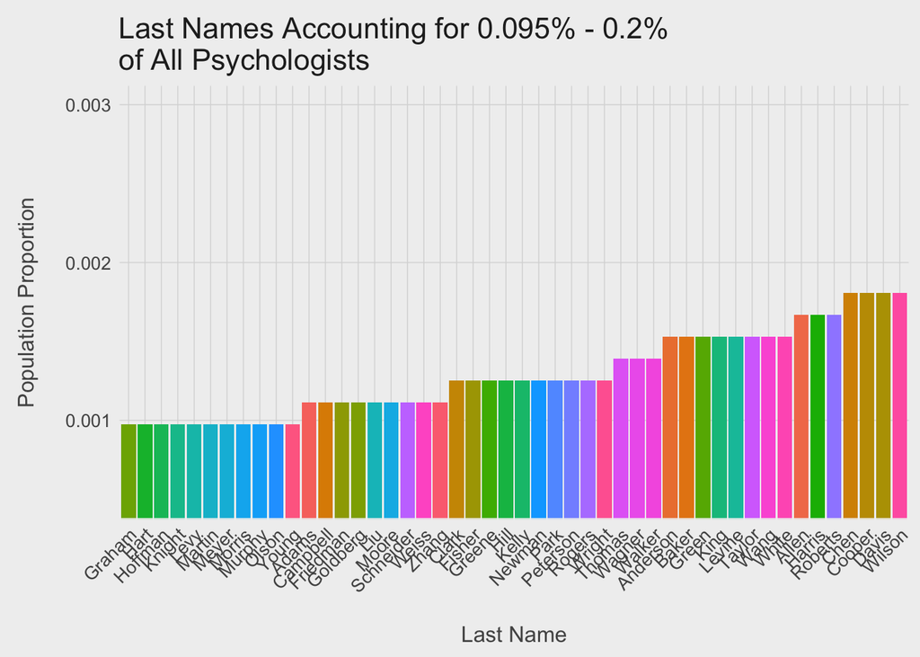

## ———————-

Next I want to compile Common, Uncommon, and Rare first names for the Game of Contacts

```
## # A tibble: 1,993 × 3
##    first_name     n freq_firstname
##         <chr> <int>          <dbl>
## 1       David   170    0.023653819
## 2     Michael   147    0.020453597
## 3        John   127    0.017670794
## 4      Robert   113    0.015722833
## 5       James   101    0.014053152
## 6     Richard    78    0.010852929
## 7    Jennifer    71    0.009878948
## 8      Daniel    66    0.009183248
## 9        Paul    65    0.009044107
## 10      Susan    57    0.007930987
## # ... with 1,983 more rows
```

By roughly cutting the total list into thirds, I’ve generated categories that include roughly equal numbers of people. They are unequal due to including all of the names at appear a certain amount of times (i.e, 5 people with the same name) in the same category. If having 5 people with the same name is considered “common”, then every name with 5 people should be in that category, not arbitrarily cut off between “common” and “uncommon”

```
## # A tibble: 3 × 2
##   category   cat
##     <fctr> <int>
## 1     rare  2344
## 2 uncommon  2400
## 3   common  2443
```

For the Game of Contacts, I will need to select 24 names:  
8 Common  
8 Uncommon  
8 Rare

From these, each should have 4 male names and 4 female names.

((will I have to enter the gender data for all names??))

5/3/17

-I think I need to go back and review the phone book method for the general population.

-I have first names that I can use for Popularity Ratio and Game of Contacts (based on commonality)

NEXT STEPS) Nail down the phone book method for general population and start making the questionnaire.